# Choosing a Level of Detail (lod)

The main function in the choroplethr package is called `choroplethr` (`?choroplethr`). It has two required parameters:

1. `df` A data.frame which contains one column named `region` and one column named `value`. df can have other columns, too - but choroplethr only cares about these columns.
2. `lod` A string which says the geographic level of detail of the data. Must be either `state`, `county` or `zip`.

As the following example shows, the choice of level of detail is important.

## State lod

choroplethr comes with a dataset, `df_pop_state`, which contains 2012 population estimates for US states.

```r
library(choroplethr)
data(choroplethr)

head(df_pop_state)
```

```
##       region    value
## 1    Alabama  4777326
## 2     Alaska   711139
## 3    Arizona  6410979
## 4   Arkansas  2916372
## 5 California 37325068
## 6   Colorado  5042853
```

When calling `choroplethr` with state level data, `region` must contain state names (e.g. “California” or “CA”).

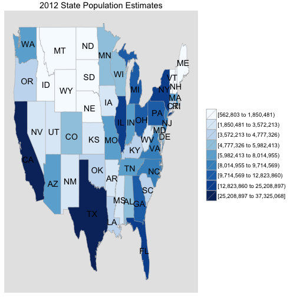

```r
choroplethr(df_pop_state, "state", title = "2012 State Population Estimates")
```

choroplethr renders state choropleths of the lower 48 states. An optional parameter, `showLabels`, determines whether to include state abbreviations in the image.

## County lod

choroplethr comes with a dataset, `df_pop_county`, which contains 2012 population estimates for US counties.

```r
head(df_pop_county)
```

```
##   region  value
## 1   1001  54590
## 2   1003 183226
## 3   1005  27469
## 4   1007  22769
## 5   1009  57466
## 6   1011  10779
```

When calling `choroplethr` with county level data, `region` must contain [county FIPS codes](http://en.wikipedia.org/wiki/FIPS_county_code).

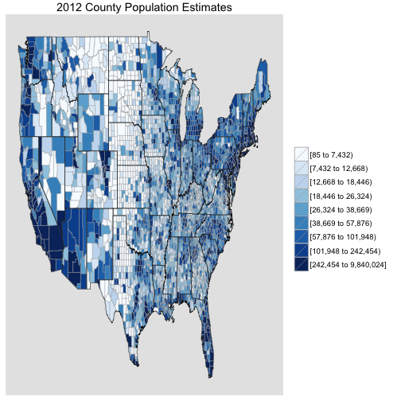

```r
choroplethr(df_pop_county, "county", title = "2012 County Population Estimates")
```

choroplethr renders county maps with an outline of state boundaries. There are over 3,000 counties in the lower 48 states.

## ZIP lod

`choroplethr` comes with a dataset, `df_pop_zip`, which contains 2012 population estimates for US [ZIP Code Tabulated Areas (ZCTAs)](https://www.census.gov/geo/reference/zctas.html). ZCTAs are created and maintained by the US Census Bureau and can be considered approximations of US Postal Codes.

```r
head(df_pop_zip)
```

```
##   region value
## 1  00601 18544
## 2  00602 41640
## 3  00603 54540
## 4  00606  6593
## 5  00610 29141
## 6  00612 69017
```

When calling `choroplethr` with ZIP level data, `region` must contain 5 digit ZIP codes.

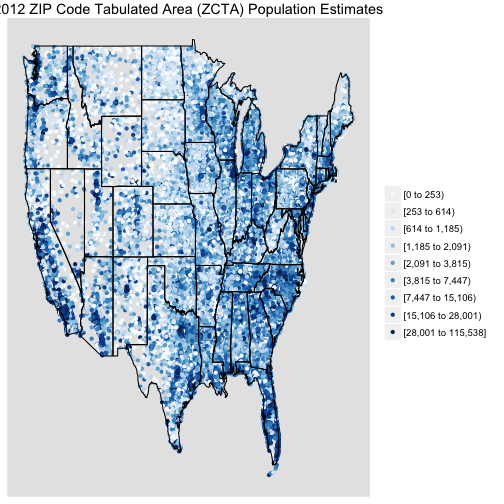

```r
choroplethr(df_pop_zip, "zip", title = "2012 ZIP Code Tabulated Area (ZCTA) Population Estimates")
```

choroplethr renders ZIP level maps as scatterplots. The longitude and latitude of each ZIP code comes from the [zipcode](http://cran.r-project.org/web/packages/zipcode/index.html) package. These are technically not choropleth maps because they do not show the boundaries of the ZIP codes.